# Digitala perspektiv på varumärken

SKOC26: Varumärkeskommunikation VT25  
Moment 2: Varumärkning av konsumentprodukter

nils.holmberg@iko.lu.se

## Introduction

[figure not shown]

## **Characteristics of Web 2.0**

- Users actively create, share, and engage with content rather than just consuming it.
- Websites are dynamic, featuring social media integration, real-time updates, and multimedia.
- Interactivity is a key feature, with comments, likes, and user-generated content driving engagement.
- Platforms rely on AI-driven algorithms to personalize content and ads.
- Monetization comes from ads, data collection, and influencer partnerships.

[figure not shown]

## **Brand Communication under Web 2.0**

- Brands engage with audiences through interactive social media campaigns.
- Influencer marketing helps brands reach niche and highly engaged communities.
- Data-driven targeting enables personalized advertisements based on user behavior.
- User-generated content builds trust and authenticity for brand messaging.
- Brands use storytelling through multimedia content like videos, blogs, and podcasts.

[figure not shown]

## **Characteristics of Web 1.0**

- Websites were static, with limited interactivity and primarily text-based content.
- Users could only consume information without the ability to comment or engage.
- HTML-based pages were manually updated with no real-time dynamic content.
- Advertising relied on simple banner ads with no personalization.
- Communication was one-way, with brands and website owners controlling the message.

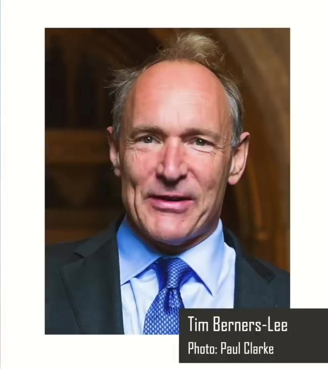

## **Brand Communication under Web 1.0**

- Companies used static websites to provide basic company information and contact details.
- Marketing relied on banner ads, email campaigns, and simple digital brochures.
- Brands had limited audience feedback and engagement due to the lack of interactivity.
- Customers had to reach out through phone or email rather than engaging online.
- Brand messaging was controlled and not influenced by customer-generated content.

[figure not shown]

## **Digital Brand Communication Channels**

- Organizational `websites` and content marketing (news, blogs, etc)
- `Search engine` marketing (SEO & PPC) drives visibility through platforms like Google and Bing.
- `Social media` platforms (Facebook, Instagram, Twitter) enable direct brand-consumer engagement.
- Display and `online video` ads generate awareness through programmatic advertising and YouTube campaigns.

## **Websites under Web 1.0**

- Websites functioned as static brochures with fixed content and little to no updates.
- Design was minimal, often featuring basic HTML with text-heavy layouts.
- Navigation was straightforward, with hierarchical menus and no personalization.
- Content was mostly company-driven with no community participation or discussion.
- There were no user accounts, commenting systems, or social media integrations.

[figure not shown]

## **Websites under Web 1.0 (Amazon)**

[figure not shown]

## **Brand Communication on Websites Today**

- Websites are interactive platforms for e-commerce, blogs, and customer engagement.
- Brands use AI-powered chatbots to provide instant customer support.
- Personalized user experiences are driven by cookies, analytics, and machine learning.
- Video, social media integration, and immersive visuals enhance engagement.
- SEO and content marketing help brands improve visibility in search results.

[figure not shown]

## **Search Engines under Web 1.0**

- Search engines were basic directories that listed web pages based on keywords.
- Algorithms were simple and relied heavily on exact keyword matches.
- Results were often cluttered with low-quality or irrelevant content.
- There were no personalized search results or AI-driven recommendations.
- Ranking manipulation was easy, as search engines lacked sophisticated ranking systems.

[figure not shown]

## **Brand Communication in Search Engines Today**

- SEO strategies help brands improve their rankings and visibility in search results.
- Paid search advertising (Google Ads) enables targeted marketing based on user intent.
- AI and machine learning help search engines deliver more personalized results.
- Featured snippets and zero-click searches impact how brands optimize content.
- Voice search optimization is becoming essential for brands in digital marketing.

[figure not shown]

## **Social Media under Web 1.0**

- There were no mainstream social media platforms as we know them today.
- Early forums and message boards were the closest form of online social interaction.
- Users connected through simple discussion boards with no real-time updates.
- Social networking was limited to email lists and early instant messaging platforms.
- Content sharing was minimal, with no easy way to distribute multimedia.

❌

## **Brand Communication in Social Media Today**

- Brands leverage social media platforms to engage directly with customers.
- Influencer collaborations drive word-of-mouth marketing and brand awareness.
- Paid social media advertising enables brands to target specific demographics.
- Interactive formats like live streaming, polls, and stories enhance engagement.
- Community management and brand reputation rely on real-time social interactions.

[figure not shown]

## **Online Video under Web 1.0**

- Video content was rare due to slow internet speeds and bandwidth limitations.
- Early video platforms had poor resolution and buffering issues.
- Users primarily downloaded videos instead of streaming them online.
- There was no mainstream video-sharing platform like YouTube.
- Brands relied on TV and DVDs rather than digital video for marketing.

❌

## **Brand Communication in Online Video Today**

- Brands use YouTube, TikTok, and Instagram Reels to connect with audiences.
- Short-form video content dominates, driving engagement and virality.
- Video ads, influencer collaborations, and live streaming create immersive brand experiences.
- AI-driven recommendations ensure that branded content reaches relevant users.
- Shoppable videos and interactive elements allow direct customer conversions.

[figure not shown]

## **Influencer marketing**

- Influencer marketing is a digital strategy where brands collaborate with online personalities to promote products.
- Influencers leverage their social media presence to engage and persuade audiences.
- Trust and authenticity are key, as influencers often feel more relatable than traditional celebrities.
- Brands partner with influencers based on their niche, audience size, and engagement rates.
- The effectiveness of influencer marketing is measured through reach, engagement, and conversion rates.

[figure not shown]

## **Challenges with Influencer Marketing**

- Authenticity concerns arise as audiences question paid partnerships and sponsored content.
- Brands struggle with tracking ROI and measuring the real impact of influencer campaigns.
- Algorithm changes on platforms like Instagram and TikTok can reduce influencer reach overnight.
- Fake followers and engagement manipulation make it hard to assess influencer credibility.
- Regulatory challenges require transparency in sponsorship disclosure and advertising laws.

[figure not shown]

## **Facebook and Instagram**

- Facebook is more text-based and community-driven, while Instagram focuses on visual content.
- Facebook supports long-form posts, groups, and events, whereas Instagram thrives on images, videos, and Stories.
- Facebook’s algorithm prioritizes engagement within personal networks, while Instagram’s highlights trending and aesthetic content.
- Instagram’s younger audience prefers short, visually appealing content, whereas Facebook appeals to a broader demographic.
- Facebook fosters discussions through comments and groups, while Instagram emphasizes direct engagement through likes and shares.

[figure not shown]

## **How is TikTok different?**

- TikTok is video-centric, prioritizing short, engaging clips with high viral potential.
- The “For You Page” (FYP) algorithm drives content discovery based on user behavior rather than follower count.
- Unlike other platforms, TikTok trends shape content creation, leading to participatory marketing.
- Sound and music play a crucial role in making TikTok content engaging and shareable.
- TikTok’s audience skews younger, with Gen Z dominating the platform.

[figure not shown]

## **User-generated content**

- User-generated content (UGC) is any digital content created by consumers rather than brands.
- UGC includes social media posts, reviews, testimonials, and brand-related memes.
- Brands leverage UGC to enhance authenticity and build trust with their audience.
- Viral UGC can significantly amplify brand awareness with minimal marketing spend.
- Platforms like TikTok, Instagram, and Reddit thrive on user-created content.

[figure not shown]

## **Online personalization**

- Online personalization tailors content, ads, and experiences based on user data.
- Websites use cookies, browsing history, and AI to predict user preferences.
- Personalized recommendations improve user engagement and sales conversion rates.
- While convenient, excessive personalization can create “filter bubbles” limiting exposure to diverse perspectives.
- Ethical concerns arise over data privacy and how companies handle personal information.

[figure not shown]

## **Online surveillance technology**

- Online surveillance tracks user behavior through cookies, IP tracking, and metadata collection.
- Governments and corporations use surveillance for security, targeted advertising, and data analysis.
- Social media platforms collect vast amounts of data to refine ad targeting.
- Facial recognition, location tracking, and AI-driven monitoring are expanding digital surveillance capabilities.
- Critics argue that online surveillance threatens privacy and digital freedom.

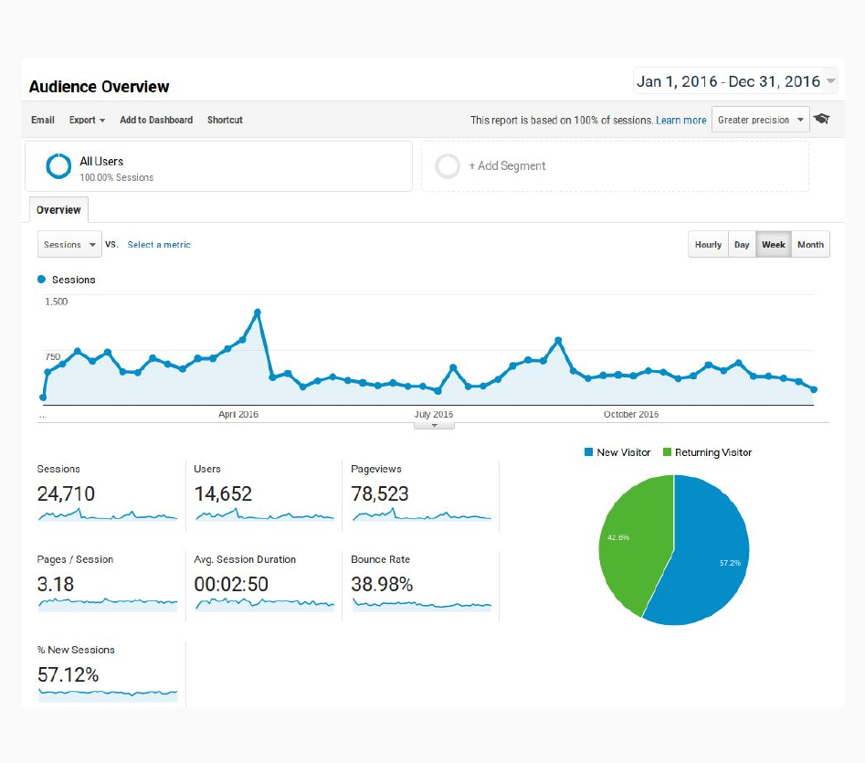

## **Personal integrity under Web 2.0**

- Privacy-focused search engines like DuckDuckGo and Brave limit online tracking.
- GDPR and other data protection laws enforce transparency and user consent.
- Encrypted messaging apps (Signal, Telegram) help users communicate securely.
- Decentralized platforms give users control over their data and digital identity.
- Browser extensions and VPNs provide additional layers of online privacy.

[figure not shown]

## Märkeskulturer

- Branding ses som en del av konsumtionskulturer och samhällsstrukturer.
- Konsumenter tolkar och omskapar varumärken inom sina kulturella sammanhang.
- Skiftet från transaktionsbaserad marknadsföring till upplevelsebaserad branding.
- Varumärkens identitet formas genom interaktioner mellan företag och konsumenter.

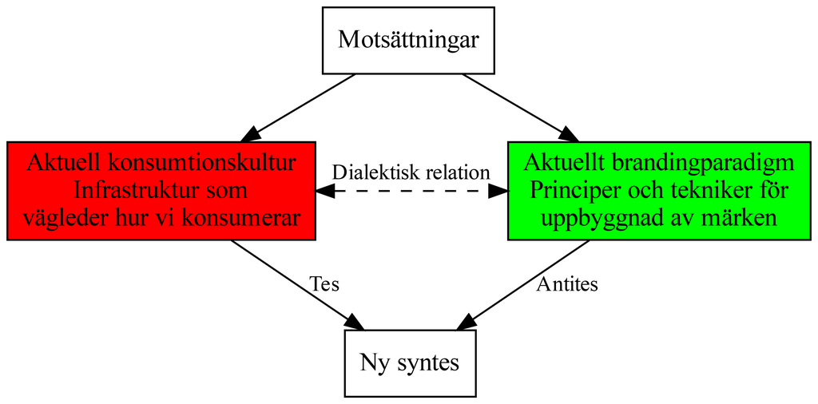

## **Characteristics of Web 3.0**

- Web 3.0 is decentralized, built on blockchain technology to reduce reliance on Big Tech.
- Users own and control their data, reducing corporate data exploitation.
- AI and machine learning enhance personalized and context-aware experiences.
- Cryptocurrencies and smart contracts enable secure, transparent transactions.
- Web 3.0 fosters decentralized applications (dApps) and community-driven governance models.

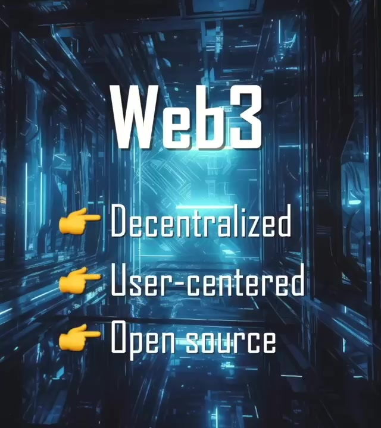

## 👉 **Decentralization**

- Power shifts from centralized authorities (governments, corporations) to distributed networks.
- Users gain greater control over data, transactions, and digital identity.
- Blockchain technology enables peer-to-peer interactions without intermediaries.
- Decentralized finance (DeFi) eliminates reliance on traditional banking systems.
- Governance in decentralized ecosystems is driven by community-led decision-making.

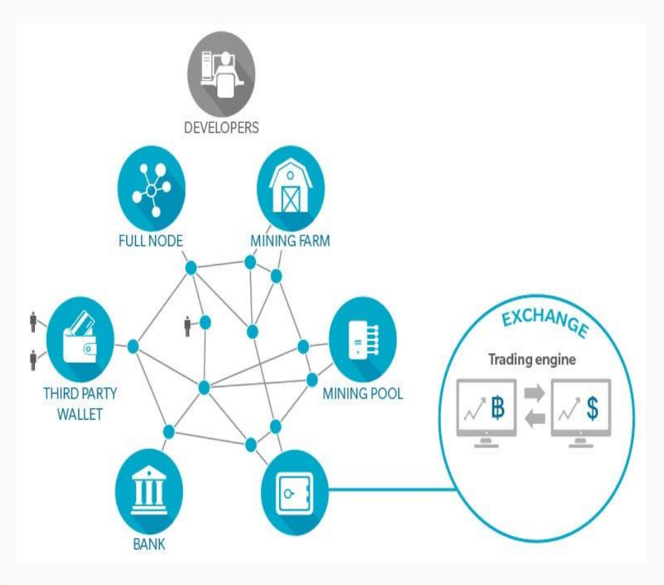

## 👉 **Privacy & Digital Ownership**

- Users regain control over personal data instead of relying on centralized corporations.
- Encryption and blockchain ensure secure and transparent data handling.
- Web 3.0 shifts ownership models from platforms to individual users.
- Digital wallets allow users to store and trade assets without third-party control.
- Decentralized applications (dApps) provide privacy-focused alternatives to traditional services.

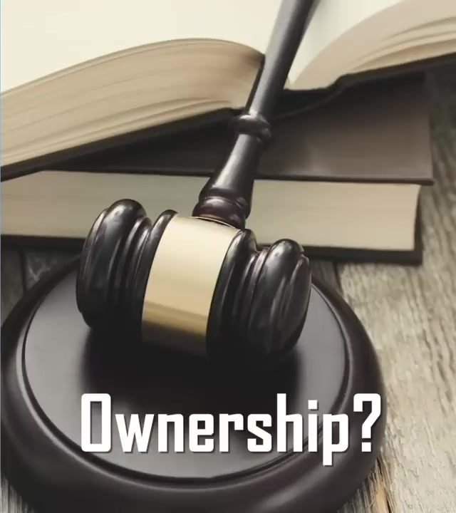

## 👉 Open Source Software

- **Transparent Codebases**: Web3 projects are often built on open-source protocols, allowing anyone to audit, modify, and contribute to the code.
- **Trustless & Verifiable Systems**: Open-source smart contracts enable trustless interactions, as users can verify functionality and security without relying on intermediaries.
- **Community-Driven Development**: Unlike traditional closed systems, Web3 encourages public participation in governance and improvements through open-source frameworks.

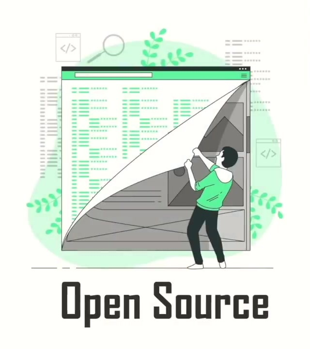

## **Blockchain Technology**

- A distributed ledger system ensures secure, transparent, and immutable transactions.
- Consensus mechanisms like Proof of Work (PoW) and Proof of Stake (PoS) validate transactions.
- Eliminates the need for intermediaries, reducing fraud and increasing efficiency.
- Smart contracts enable automated execution of agreements without central oversight.
- Used in finance, supply chains, healthcare, and digital identity verification.

## **Cryptocurrency**

- Digital currencies operate on blockchain technology, eliminating the need for banks.
- Bitcoin was the first cryptocurrency, but thousands of alternatives (altcoins) exist.
- Cryptocurrencies provide decentralized finance (DeFi) solutions for global transactions.
- Wallets store private keys that give users control over their digital assets.
- Price volatility, regulatory challenges, and adoption barriers impact mainstream use.

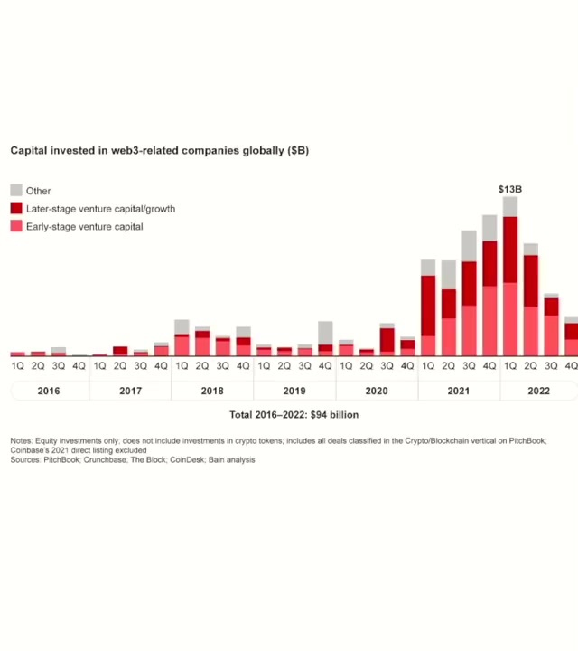

## **Non-Fungible Tokens (NFTs)**

- NFTs represent unique digital assets stored on a blockchain.
- Used in digital art, gaming, virtual real estate, and collectibles.
- Provide proof of ownership and authenticity through smart contracts.
- NFT marketplaces (OpenSea, Rarible) facilitate trading and auctions.
- Critics raise concerns over environmental impact and speculative bubbles.

[figure not shown]

## **Decentralized Applications (dApps)**

- Applications that run on a blockchain instead of centralized servers.
- Provide censorship-resistant alternatives to traditional platforms.
- Users interact with dApps through Web 3.0 wallets like MetaMask.
- Popular dApp categories include DeFi, gaming, and social media.
- Developers build dApps using smart contracts for secure and transparent execution.

[figure not shown]

## **Decentralized Autonomous Organizations (DAOs)**

- Community-driven organizations governed by smart contracts instead of centralized leadership.
- Members vote on proposals using governance tokens.
- DAOs manage treasuries, fund projects, and make collective decisions.
- Used in investment funds, non-profits, and metaverse projects.
- Challenges include governance disputes, scalability, and security vulnerabilities.

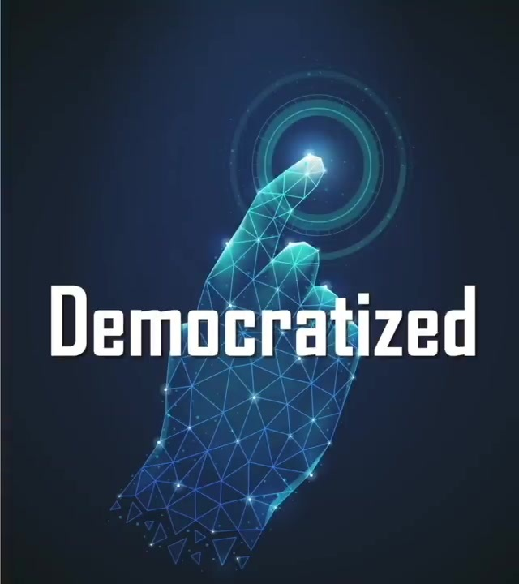

## **Metaverse**

- A virtual, interconnected digital world where users interact using avatars.
- Built on blockchain technology to enable true ownership of digital assets.
- Used for gaming, workspaces, education, and social experiences.
- NFTs and cryptocurrencies power metaverse economies and transactions.
- Major tech companies (Meta, Microsoft) are investing in metaverse development.

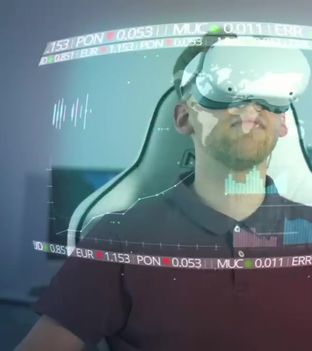

## Brand Communication in Metaverse

- **Virtual Brand Ownership** – NFTs allow consumers to “own” digital brand assets, deepening brand engagement.
- **Expanded Brand Spaces** – The metaverse creates immersive brand experiences beyond physical products and ads.
- **Decentralized Branding** – Consumers gain more control over brand narratives through blockchain-based assets.
- **Symbolic Capital in Digital Worlds** – Virtual goods and NFTs act as new status symbols, redefining brand value.
- **From Exclusivity to Accessibility** – NFTs promise scarcity, yet metaverse spaces foster open, participatory brand interactions.

## Artificial Intelligence

- **Artificial Intelligence (AI)**: The broad field of creating machines or software that can simulate human intelligence, including reasoning, problem-solving, and decision-making.
- **Machine Learning (ML)**: A subset of AI where systems learn patterns from data and improve their performance without being explicitly programmed.
- **Deep Learning (DL)**: A specialized branch of ML that uses multi-layered neural networks to process complex data and achieve human-like recognition in tasks such as image and speech analysis.

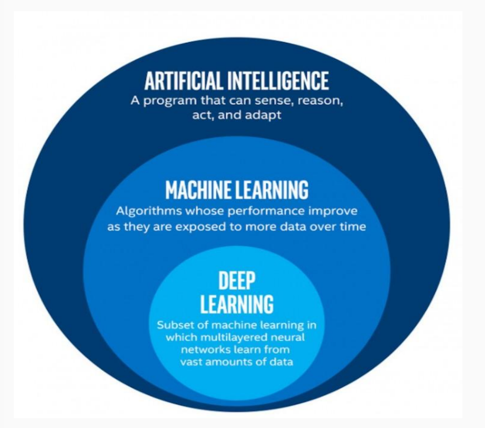

## Deep learning

- Deep learning uses multi-layered neural networks to process vast amounts of data for pattern recognition.
- It powers AI applications like image recognition, speech processing, and automated decision-making.
- Unlike traditional machine learning, deep learning models self-improve by adjusting internal parameters.

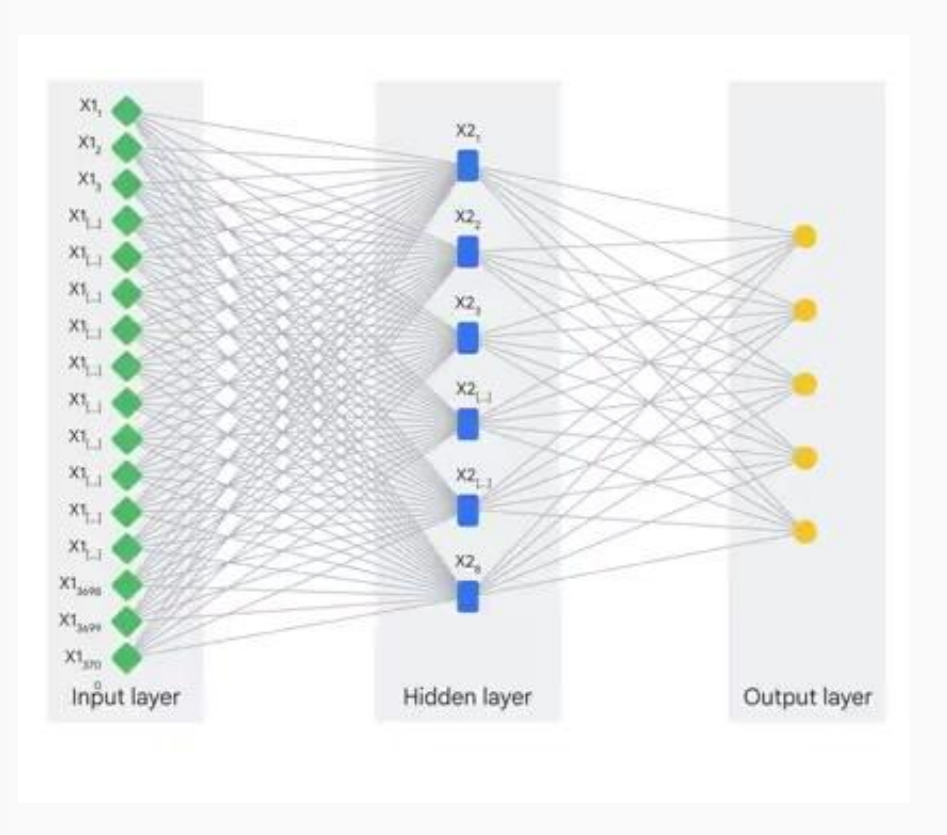

## Predictive AI

- Predictive AI analyzes historical data to forecast trends, behaviors, and outcomes.
- Businesses use it to anticipate customer needs, optimize operations, and prevent potential risks.
- Predictive AI enhances decision-making by providing data-driven insights in real-time.
- Industries like finance, marketing, and healthcare benefit from predictive AI for strategic planning.

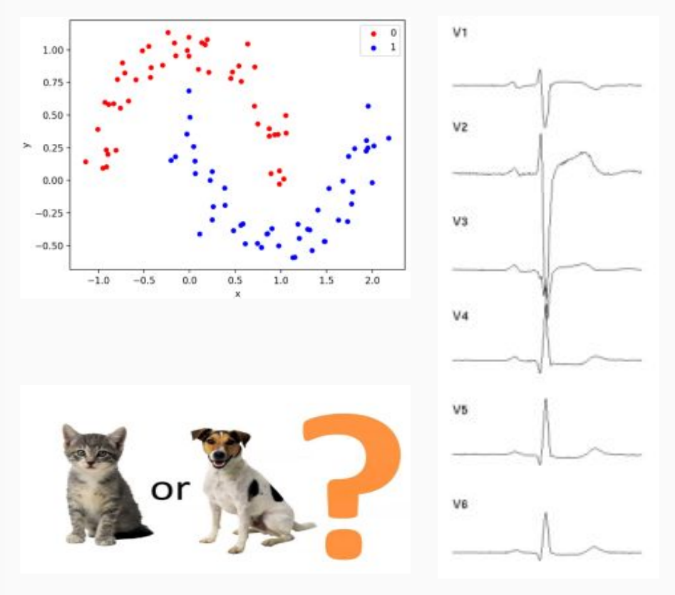